# Risk Factor Analysis

## Outcome Variable

**Outcome Variable:** ever_stunted

## Predictor Variables

**Intervention Variable:** safeh20

**Adjustment Set:**

- arm
- W_mage
- meducyrs
- feducyrs
- hhwealth_quart
- hfoodsec
- W_mhtcm
- W_mwtkg
- W_mbmi
- W_nrooms
- W_nchldlt5
- W_parity
- impfloor
- impsan
- delta_W_mage
- delta_meducyrs
- delta_feducyrs
- delta_hhwealth_quart
- delta_hfoodsec
- delta_W_mhtcm
- delta_W_mwtkg
- delta_W_mbmi
- delta_W_nrooms
- delta_W_nchldlt5
- delta_W_parity
- delta_impfloor
- delta_impsan

## Stratifying Variables

The analysis was stratified on these variable(s):

- agecat
- studyid
- country

## Data Summary

| agecat | studyid | country | safeh20 | ever_stunted | n_cell | n |
| --- | --- | --- | --- | --- | --- | --- |
| 0-24 months (no birth st.) | CONTENT | PERU | 1 | 0 | 46 | 55 |
| 0-24 months (no birth st.) | CONTENT | PERU | 1 | 1 | 6 | 55 |
| 0-24 months (no birth st.) | CONTENT | PERU | 0 | 0 | 3 | 55 |
| 0-24 months (no birth st.) | CONTENT | PERU | 0 | 1 | 0 | 55 |
| 0-24 months (no birth st.) | JiVitA-3 | BANGLADESH | 1 | 0 | 13707 | 18357 |
| 0-24 months (no birth st.) | JiVitA-3 | BANGLADESH | 1 | 1 | 4626 | 18357 |
| 0-24 months (no birth st.) | JiVitA-3 | BANGLADESH | 0 | 0 | 18 | 18357 |
| 0-24 months (no birth st.) | JiVitA-3 | BANGLADESH | 0 | 1 | 6 | 18357 |
| 0-24 months (no birth st.) | JiVitA-4 | BANGLADESH | 1 | 0 | 2268 | 3875 |
| 0-24 months (no birth st.) | JiVitA-4 | BANGLADESH | 1 | 1 | 1606 | 3875 |
| 0-24 months (no birth st.) | JiVitA-4 | BANGLADESH | 0 | 0 | 1 | 3875 |
| 0-24 months (no birth st.) | JiVitA-4 | BANGLADESH | 0 | 1 | 0 | 3875 |
| 0-24 months (no birth st.) | LCNI-5 | MALAWI | 1 | 0 | 243 | 521 |
| 0-24 months (no birth st.) | LCNI-5 | MALAWI | 1 | 1 | 186 | 521 |
| 0-24 months (no birth st.) | LCNI-5 | MALAWI | 0 | 0 | 53 | 521 |
| 0-24 months (no birth st.) | LCNI-5 | MALAWI | 0 | 1 | 39 | 521 |
| 0-24 months (no birth st.) | MAL-ED | BANGLADESH | 1 | 0 | 0 | 203 |
| 0-24 months (no birth st.) | MAL-ED | BANGLADESH | 1 | 1 | 0 | 203 |
| 0-24 months (no birth st.) | MAL-ED | BANGLADESH | 0 | 0 | 93 | 203 |
| 0-24 months (no birth st.) | MAL-ED | BANGLADESH | 0 | 1 | 110 | 203 |
| 0-24 months (no birth st.) | MAL-ED | BRAZIL | 1 | 0 | 0 | 128 |
| 0-24 months (no birth st.) | MAL-ED | BRAZIL | 1 | 1 | 0 | 128 |
| 0-24 months (no birth st.) | MAL-ED | BRAZIL | 0 | 0 | 110 | 128 |
| 0-24 months (no birth st.) | MAL-ED | BRAZIL | 0 | 1 | 18 | 128 |
| 0-24 months (no birth st.) | MAL-ED | INDIA | 1 | 0 | 0 | 197 |
| 0-24 months (no birth st.) | MAL-ED | INDIA | 1 | 1 | 0 | 197 |
| 0-24 months (no birth st.) | MAL-ED | INDIA | 0 | 0 | 89 | 197 |
| 0-24 months (no birth st.) | MAL-ED | INDIA | 0 | 1 | 108 | 197 |
| 0-24 months (no birth st.) | MAL-ED | NEPAL | 1 | 0 | 0 | 206 |
| 0-24 months (no birth st.) | MAL-ED | NEPAL | 1 | 1 | 1 | 206 |

[output cut: 150 more lines]

The following strata were considered:

- agecat: 0-24 months (no birth st.), studyid: CONTENT, country: PERU
- agecat: 0-24 months (no birth st.), studyid: JiVitA-3, country: BANGLADESH
- agecat: 0-24 months (no birth st.), studyid: JiVitA-4, country: BANGLADESH
- agecat: 0-24 months (no birth st.), studyid: LCNI-5, country: MALAWI
- agecat: 0-24 months (no birth st.), studyid: MAL-ED, country: BANGLADESH
- agecat: 0-24 months (no birth st.), studyid: MAL-ED, country: BRAZIL
- agecat: 0-24 months (no birth st.), studyid: MAL-ED, country: INDIA
- agecat: 0-24 months (no birth st.), studyid: MAL-ED, country: NEPAL
- agecat: 0-24 months (no birth st.), studyid: MAL-ED, country: PERU
- agecat: 0-24 months (no birth st.), studyid: MAL-ED, country: SOUTH AFRICA
- agecat: 0-24 months (no birth st.), studyid: MAL-ED, country: TANZANIA, UNITED REPUBLIC OF
- agecat: 0-24 months (no birth st.), studyid: NIH-Birth, country: BANGLADESH
- agecat: 0-24 months (no birth st.), studyid: NIH-Crypto, country: BANGLADESH
- agecat: 0-24 months (no birth st.), studyid: PROVIDE, country: BANGLADESH
- agecat: 0-24 months (no birth st.), studyid: SAS-FoodSuppl, country: INDIA
- agecat: 0-6 months (no birth st.), studyid: CONTENT, country: PERU
- agecat: 0-6 months (no birth st.), studyid: JiVitA-3, country: BANGLADESH
- agecat: 0-6 months (no birth st.), studyid: JiVitA-4, country: BANGLADESH
- agecat: 0-6 months (no birth st.), studyid: LCNI-5, country: MALAWI
- agecat: 0-6 months (no birth st.), studyid: MAL-ED, country: BANGLADESH
- agecat: 0-6 months (no birth st.), studyid: MAL-ED, country: BRAZIL
- agecat: 0-6 months (no birth st.), studyid: MAL-ED, country: INDIA
- agecat: 0-6 months (no birth st.), studyid: MAL-ED, country: NEPAL
- agecat: 0-6 months (no birth st.), studyid: MAL-ED, country: PERU
- agecat: 0-6 months (no birth st.), studyid: MAL-ED, country: SOUTH AFRICA
- agecat: 0-6 months (no birth st.), studyid: MAL-ED, country: TANZANIA, UNITED REPUBLIC OF
- agecat: 0-6 months (no birth st.), studyid: NIH-Birth, country: BANGLADESH
- agecat: 0-6 months (no birth st.), studyid: NIH-Crypto, country: BANGLADESH
- agecat: 0-6 months (no birth st.), studyid: PROVIDE, country: BANGLADESH
- agecat: 0-6 months (no birth st.), studyid: SAS-FoodSuppl, country: INDIA
- agecat: 6-24 months, studyid: CONTENT, country: PERU
- agecat: 6-24 months, studyid: JiVitA-3, country: BANGLADESH
- agecat: 6-24 months, studyid: JiVitA-4, country: BANGLADESH
- agecat: 6-24 months, studyid: LCNI-5, country: MALAWI
- agecat: 6-24 months, studyid: MAL-ED, country: BANGLADESH
- agecat: 6-24 months, studyid: MAL-ED, country: BRAZIL
- agecat: 6-24 months, studyid: MAL-ED, country: INDIA
- agecat: 6-24 months, studyid: MAL-ED, country: NEPAL
- agecat: 6-24 months, studyid: MAL-ED, country: PERU
- agecat: 6-24 months, studyid: MAL-ED, country: SOUTH AFRICA
- agecat: 6-24 months, studyid: MAL-ED, country: TANZANIA, UNITED REPUBLIC OF
- agecat: 6-24 months, studyid: NIH-Birth, country: BANGLADESH
- agecat: 6-24 months, studyid: NIH-Crypto, country: BANGLADESH
- agecat: 6-24 months, studyid: PROVIDE, country: BANGLADESH
- agecat: 6-24 months, studyid: SAS-FoodSuppl, country: INDIA

### Dropped Strata

Some strata were dropped due to rare outcomes:

- agecat: 0-24 months (no birth st.), studyid: CONTENT, country: PERU
- agecat: 0-24 months (no birth st.), studyid: JiVitA-4, country: BANGLADESH
- agecat: 0-24 months (no birth st.), studyid: MAL-ED, country: BANGLADESH
- agecat: 0-24 months (no birth st.), studyid: MAL-ED, country: BRAZIL
- agecat: 0-24 months (no birth st.), studyid: MAL-ED, country: INDIA
- agecat: 0-24 months (no birth st.), studyid: MAL-ED, country: NEPAL
- agecat: 0-24 months (no birth st.), studyid: NIH-Birth, country: BANGLADESH
- agecat: 0-24 months (no birth st.), studyid: NIH-Crypto, country: BANGLADESH
- agecat: 0-24 months (no birth st.), studyid: PROVIDE, country: BANGLADESH
- agecat: 0-24 months (no birth st.), studyid: SAS-FoodSuppl, country: INDIA
- agecat: 0-6 months (no birth st.), studyid: CONTENT, country: PERU
- agecat: 0-6 months (no birth st.), studyid: JiVitA-3, country: BANGLADESH
- agecat: 0-6 months (no birth st.), studyid: JiVitA-4, country: BANGLADESH
- agecat: 0-6 months (no birth st.), studyid: LCNI-5, country: MALAWI
- agecat: 0-6 months (no birth st.), studyid: MAL-ED, country: BANGLADESH
- agecat: 0-6 months (no birth st.), studyid: MAL-ED, country: BRAZIL
- agecat: 0-6 months (no birth st.), studyid: MAL-ED, country: INDIA
- agecat: 0-6 months (no birth st.), studyid: MAL-ED, country: NEPAL
- agecat: 0-6 months (no birth st.), studyid: NIH-Birth, country: BANGLADESH
- agecat: 0-6 months (no birth st.), studyid: NIH-Crypto, country: BANGLADESH
- agecat: 0-6 months (no birth st.), studyid: PROVIDE, country: BANGLADESH
- agecat: 0-6 months (no birth st.), studyid: SAS-FoodSuppl, country: INDIA
- agecat: 6-24 months, studyid: CONTENT, country: PERU
- agecat: 6-24 months, studyid: JiVitA-3, country: BANGLADESH
- agecat: 6-24 months, studyid: JiVitA-4, country: BANGLADESH
- agecat: 6-24 months, studyid: MAL-ED, country: BANGLADESH
- agecat: 6-24 months, studyid: MAL-ED, country: BRAZIL
- agecat: 6-24 months, studyid: MAL-ED, country: INDIA
- agecat: 6-24 months, studyid: MAL-ED, country: NEPAL
- agecat: 6-24 months, studyid: MAL-ED, country: PERU
- agecat: 6-24 months, studyid: NIH-Birth, country: BANGLADESH
- agecat: 6-24 months, studyid: NIH-Crypto, country: BANGLADESH
- agecat: 6-24 months, studyid: PROVIDE, country: BANGLADESH
- agecat: 6-24 months, studyid: SAS-FoodSuppl, country: INDIA

## Methods Detail

We’re interested in the causal parameters $E[Y_a]$ for all values of $a \in \mathcal{A}$. These parameters represent the mean outcome if, possibly contrary to fact, we intervened to set all units to have $A=a$. Under the randomization and positivity assumptions, these are identified by the statistical parameters $\psi_a=E_W[E_{Y|A,W}(Y|A=a,W)]$. In addition, we’re interested in the mean of $Y$, $E[Y]$ under no intervention (the observed mean). We will estimate these parameters by using SuperLearner to fit the relevant likelihood factors – $E_{Y|A,W}(Y|A=a,W)$ and $p(A=a|W)$, and then updating our likelihood fit using a joint TMLE.

For unadjusted analyses ($W=\{\}$), initial likelihoods were estimated using Lrnr_glm to estimate the simple $E(Y|A)$ and Lrnr_mean to estimate $p(A)$. For adjusted analyses, a small library containing Lrnr_glmnet, Lrnr_xgboost, and Lrnr_mean was used.

Having estimated these parameters, we will then use the delta method to estimate relative risks and attributable risks relative to a prespecified baseline level of $A$.

# Results Detail

## Results Plots

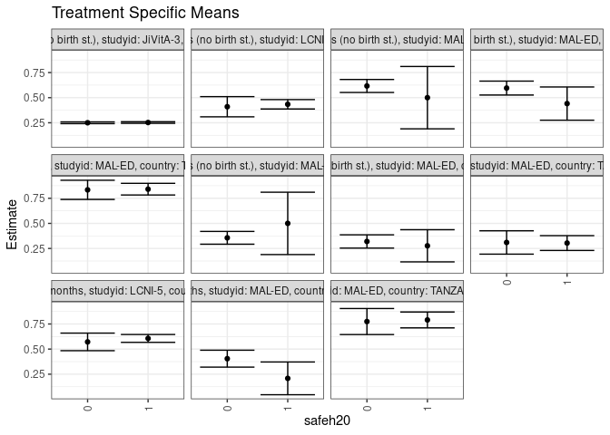

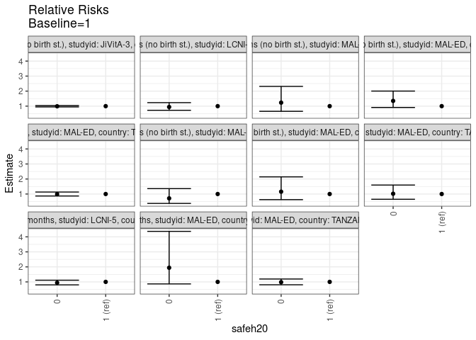

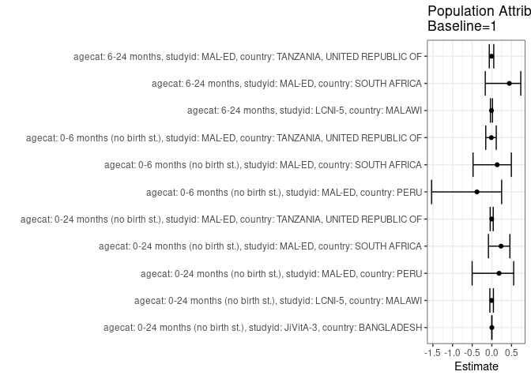

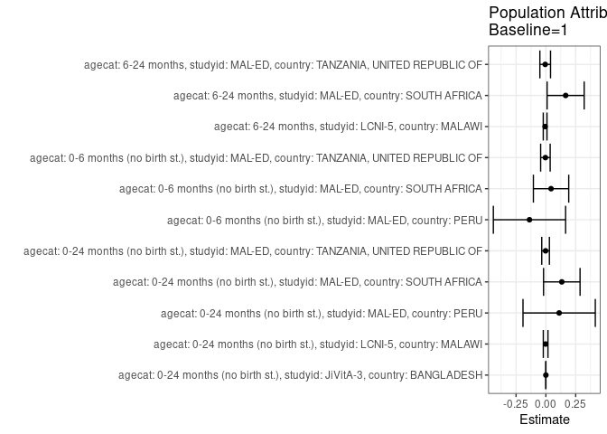

## Results Table

### Parameter: TSM

| agecat | studyid | country | intervention_level | baseline_level | estimate | ci_lower | ci_upper |
| --- | --- | --- | --- | --- | --- | --- | --- |
| 0-24 months (no birth st.) | JiVitA-3 | BANGLADESH | 1 | NA | 0.2523319 | 0.2444053 | 0.2602584 |
| 0-24 months (no birth st.) | JiVitA-3 | BANGLADESH | 0 | NA | 0.2500000 | 0.2415133 | 0.2584867 |
| 0-24 months (no birth st.) | LCNI-5 | MALAWI | 1 | NA | 0.4338940 | 0.3871431 | 0.4806450 |
| 0-24 months (no birth st.) | LCNI-5 | MALAWI | 0 | NA | 0.4097164 | 0.3090884 | 0.5103444 |
| 0-24 months (no birth st.) | MAL-ED | PERU | 1 | NA | 0.5000000 | 0.1894236 | 0.8105764 |
| 0-24 months (no birth st.) | MAL-ED | PERU | 0 | NA | 0.6164384 | 0.5518969 | 0.6809798 |
| 0-24 months (no birth st.) | MAL-ED | SOUTH AFRICA | 1 | NA | 0.4408966 | 0.2754255 | 0.6063677 |
| 0-24 months (no birth st.) | MAL-ED | SOUTH AFRICA | 0 | NA | 0.5954879 | 0.5260594 | 0.6649164 |
| 0-24 months (no birth st.) | MAL-ED | TANZANIA, UNITED REPUBLIC OF | 1 | NA | 0.8406739 | 0.7826510 | 0.8986967 |
| 0-24 months (no birth st.) | MAL-ED | TANZANIA, UNITED REPUBLIC OF | 0 | NA | 0.8339116 | 0.7384626 | 0.9293607 |
| 0-6 months (no birth st.) | MAL-ED | PERU | 1 | NA | 0.5000000 | 0.1894236 | 0.8105764 |
| 0-6 months (no birth st.) | MAL-ED | PERU | 0 | NA | 0.3561644 | 0.2926036 | 0.4197251 |
| 0-6 months (no birth st.) | MAL-ED | SOUTH AFRICA | 1 | NA | 0.2766860 | 0.1163261 | 0.4370458 |
| 0-6 months (no birth st.) | MAL-ED | SOUTH AFRICA | 0 | NA | 0.3198032 | 0.2535807 | 0.3860256 |
| 0-6 months (no birth st.) | MAL-ED | TANZANIA, UNITED REPUBLIC OF | 1 | NA | 0.3039677 | 0.2302824 | 0.3776531 |
| 0-6 months (no birth st.) | MAL-ED | TANZANIA, UNITED REPUBLIC OF | 0 | NA | 0.3098597 | 0.1936182 | 0.4261012 |
| 6-24 months | LCNI-5 | MALAWI | 1 | NA | 0.6062678 | 0.5670802 | 0.6454553 |
| 6-24 months | LCNI-5 | MALAWI | 0 | NA | 0.5717363 | 0.4842524 | 0.6592203 |
| 6-24 months | MAL-ED | SOUTH AFRICA | 1 | NA | 0.2083333 | 0.0453292 | 0.3713374 |
| 6-24 months | MAL-ED | SOUTH AFRICA | 0 | NA | 0.4045802 | 0.3202599 | 0.4889004 |
| 6-24 months | MAL-ED | TANZANIA, UNITED REPUBLIC OF | 1 | NA | 0.7903838 | 0.7112142 | 0.8695534 |
| 6-24 months | MAL-ED | TANZANIA, UNITED REPUBLIC OF | 0 | NA | 0.7745674 | 0.6448925 | 0.9042423 |

### Parameter: E(Y)

| agecat | studyid | country | intervention_level | baseline_level | estimate | ci_lower | ci_upper |
| --- | --- | --- | --- | --- | --- | --- | --- |
| 0-24 months (no birth st.) | JiVitA-3 | BANGLADESH | NA | NA | 0.2523288 | 0.2445890 | 0.2600687 |
| 0-24 months (no birth st.) | LCNI-5 | MALAWI | NA | NA | 0.4318618 | 0.3892877 | 0.4744359 |
| 0-24 months (no birth st.) | MAL-ED | PERU | NA | NA | 0.6113537 | 0.5480828 | 0.6746246 |
| 0-24 months (no birth st.) | MAL-ED | SOUTH AFRICA | NA | NA | 0.5745614 | 0.5102450 | 0.6388778 |
| 0-24 months (no birth st.) | MAL-ED | TANZANIA, UNITED REPUBLIC OF | NA | NA | 0.8380952 | 0.7881549 | 0.8880356 |
| 0-6 months (no birth st.) | MAL-ED | PERU | NA | NA | 0.3624454 | 0.3000489 | 0.4248420 |
| 0-6 months (no birth st.) | MAL-ED | SOUTH AFRICA | NA | NA | 0.3201754 | 0.2594840 | 0.3808669 |
| 0-6 months (no birth st.) | MAL-ED | TANZANIA, UNITED REPUBLIC OF | NA | NA | 0.3000000 | 0.2378724 | 0.3621276 |
| 6-24 months | LCNI-5 | MALAWI | NA | NA | 0.6000000 | 0.5639396 | 0.6360604 |
| 6-24 months | MAL-ED | SOUTH AFRICA | NA | NA | 0.3741935 | 0.2977649 | 0.4506221 |
| 6-24 months | MAL-ED | TANZANIA, UNITED REPUBLIC OF | NA | NA | 0.7847222 | 0.7173567 | 0.8520877 |

### Parameter: RR

| agecat | studyid | country | intervention_level | baseline_level | estimate | ci_lower | ci_upper |
| --- | --- | --- | --- | --- | --- | --- | --- |
| 0-24 months (no birth st.) | JiVitA-3 | BANGLADESH | 1 | 1 | 1.0000000 | 1.0000000 | 1.000000 |
| 0-24 months (no birth st.) | JiVitA-3 | BANGLADESH | 0 | 1 | 0.9907588 | 0.9468697 | 1.036682 |
| 0-24 months (no birth st.) | LCNI-5 | MALAWI | 1 | 1 | 1.0000000 | 1.0000000 | 1.000000 |
| 0-24 months (no birth st.) | LCNI-5 | MALAWI | 0 | 1 | 0.9442776 | 0.7230624 | 1.233172 |
| 0-24 months (no birth st.) | MAL-ED | PERU | 1 | 1 | 1.0000000 | 1.0000000 | 1.000000 |
| 0-24 months (no birth st.) | MAL-ED | PERU | 0 | 1 | 1.2328767 | 0.6566758 | 2.314666 |
| 0-24 months (no birth st.) | MAL-ED | SOUTH AFRICA | 1 | 1 | 1.0000000 | 1.0000000 | 1.000000 |
| 0-24 months (no birth st.) | MAL-ED | SOUTH AFRICA | 0 | 1 | 1.3506294 | 0.9106314 | 2.003225 |
| 0-24 months (no birth st.) | MAL-ED | TANZANIA, UNITED REPUBLIC OF | 1 | 1 | 1.0000000 | 1.0000000 | 1.000000 |
| 0-24 months (no birth st.) | MAL-ED | TANZANIA, UNITED REPUBLIC OF | 0 | 1 | 0.9919562 | 0.8688485 | 1.132507 |
| 0-6 months (no birth st.) | MAL-ED | PERU | 1 | 1 | 1.0000000 | 1.0000000 | 1.000000 |
| 0-6 months (no birth st.) | MAL-ED | PERU | 0 | 1 | 0.7123288 | 0.3732540 | 1.359429 |
| 0-6 months (no birth st.) | MAL-ED | SOUTH AFRICA | 1 | 1 | 1.0000000 | 1.0000000 | 1.000000 |
| 0-6 months (no birth st.) | MAL-ED | SOUTH AFRICA | 0 | 1 | 1.1558344 | 0.6240134 | 2.140905 |
| 0-6 months (no birth st.) | MAL-ED | TANZANIA, UNITED REPUBLIC OF | 1 | 1 | 1.0000000 | 1.0000000 | 1.000000 |
| 0-6 months (no birth st.) | MAL-ED | TANZANIA, UNITED REPUBLIC OF | 0 | 1 | 1.0193834 | 0.6508120 | 1.596686 |
| 6-24 months | LCNI-5 | MALAWI | 1 | 1 | 1.0000000 | 1.0000000 | 1.000000 |
| 6-24 months | LCNI-5 | MALAWI | 0 | 1 | 0.9430426 | 0.8000953 | 1.111529 |
| 6-24 months | MAL-ED | SOUTH AFRICA | 1 | 1 | 1.0000000 | 1.0000000 | 1.000000 |
| 6-24 months | MAL-ED | SOUTH AFRICA | 0 | 1 | 1.9419847 | 0.8641652 | 4.364101 |
| 6-24 months | MAL-ED | TANZANIA, UNITED REPUBLIC OF | 1 | 1 | 1.0000000 | 1.0000000 | 1.000000 |
| 6-24 months | MAL-ED | TANZANIA, UNITED REPUBLIC OF | 0 | 1 | 0.9799889 | 0.8070327 | 1.190012 |

### Parameter: PAR

| agecat | studyid | country | intervention_level | baseline_level | estimate | ci_lower | ci_upper |
| --- | --- | --- | --- | --- | --- | --- | --- |
| 0-24 months (no birth st.) | JiVitA-3 | BANGLADESH | 1 | NA | -0.0000030 | -0.0002871 | 0.0002810 |
| 0-24 months (no birth st.) | LCNI-5 | MALAWI | 1 | NA | -0.0020322 | -0.0215358 | 0.0174713 |
| 0-24 months (no birth st.) | MAL-ED | PERU | 1 | NA | 0.1113537 | -0.1920217 | 0.4147291 |
| 0-24 months (no birth st.) | MAL-ED | SOUTH AFRICA | 1 | NA | 0.1336648 | -0.0195031 | 0.2868328 |
| 0-24 months (no birth st.) | MAL-ED | TANZANIA, UNITED REPUBLIC OF | 1 | NA | -0.0025786 | -0.0346608 | 0.0295035 |
| 0-6 months (no birth st.) | MAL-ED | PERU | 1 | NA | -0.1375546 | -0.4407488 | 0.1656397 |
| 0-6 months (no birth st.) | MAL-ED | SOUTH AFRICA | 1 | NA | 0.0434895 | -0.1047470 | 0.1917260 |
| 0-6 months (no birth st.) | MAL-ED | TANZANIA, UNITED REPUBLIC OF | 1 | NA | -0.0039677 | -0.0438474 | 0.0359119 |
| 6-24 months | LCNI-5 | MALAWI | 1 | NA | -0.0062678 | -0.0219612 | 0.0094257 |
| 6-24 months | MAL-ED | SOUTH AFRICA | 1 | NA | 0.1658602 | 0.0103500 | 0.3213705 |
| 6-24 months | MAL-ED | TANZANIA, UNITED REPUBLIC OF | 1 | NA | -0.0056616 | -0.0503785 | 0.0390553 |

### Parameter: PAF

| agecat | studyid | country | intervention_level | baseline_level | estimate | ci_lower | ci_upper |
| --- | --- | --- | --- | --- | --- | --- | --- |
| 0-24 months (no birth st.) | JiVitA-3 | BANGLADESH | 1 | NA | -0.0000121 | -0.0011383 | 0.0011129 |
| 0-24 months (no birth st.) | LCNI-5 | MALAWI | 1 | NA | -0.0047058 | -0.0509024 | 0.0394601 |
| 0-24 months (no birth st.) | MAL-ED | PERU | 1 | NA | 0.1821429 | -0.5013602 | 0.5544771 |
| 0-24 months (no birth st.) | MAL-ED | SOUTH AFRICA | 1 | NA | 0.2326380 | -0.0875060 | 0.4585369 |
| 0-24 months (no birth st.) | MAL-ED | TANZANIA, UNITED REPUBLIC OF | 1 | NA | -0.0030768 | -0.0421062 | 0.0344909 |
| 0-6 months (no birth st.) | MAL-ED | PERU | 1 | NA | -0.3795181 | -1.5324147 | 0.2485156 |
| 0-6 months (no birth st.) | MAL-ED | SOUTH AFRICA | 1 | NA | 0.1358301 | -0.4780070 | 0.4947321 |
| 0-6 months (no birth st.) | MAL-ED | TANZANIA, UNITED REPUBLIC OF | 1 | NA | -0.0132258 | -0.1553175 | 0.1113901 |
| 6-24 months | LCNI-5 | MALAWI | 1 | NA | -0.0104463 | -0.0369574 | 0.0153871 |
| 6-24 months | MAL-ED | SOUTH AFRICA | 1 | NA | 0.4432471 | -0.1675092 | 0.7344999 |
| 6-24 months | MAL-ED | TANZANIA, UNITED REPUBLIC OF | 1 | NA | -0.0072148 | -0.0658749 | 0.0482170 |